# Project: Investigate a Dataset (No-Show Appointments)

- Introduction
- Data Wrangling
- Exploratory Data Analysis
- Conclusions
- References

## Introduction

Medical appointments arrangement is an important adminstrative process to ensure proper time management for both doctors and patients. When a patient makes an appointment, receives all the instruction needed. However, number of patients do not show up. So, what are the reasons behind this problem?

This project will investigate several factors/characteristics that may affect the show-up and no-show decisions to the appointment by analysing 'noshowappointments-kagglev2-may-2016.csv' document that collects data of 110,527 medical appointments in Brazil. Each appointment includes information for 14 associated variables/characteristics, which are:

- **PatientId:** serial ID for a patient
- **AppointmentID:** serial ID for an appointment
- **Gender:** Gender of a patient (female coded as (F) or male coded as (M))
- **ScheduledDay:** The day when a patient set up an appointment
- **AppointmentDay:** The day of patient's appointment
- **Age:** Age of the patient
- **Neighbourhood:** the location of the hospital
- **Scholarship:** tells us if a patient is enrolled in Brazilian welfare program, Bolsa Família (1 for enrolled, 0 for not)
- **Hypertension and Diabetes:** tell us if a patient has the health issue or not(1 for infected, 0 for not)
- **Alcoholism:** tell us if a patient consume alcohol or not(1 for consume, 0 for not)
- **Handicap:** tell us the numbers of handicaps a patient would face
- **SMS_Received:** tells us if the patient received an SMS (1 for recieved, 0 for not)
- **No_Show:** whether the patient show-up or not (Yes for no-show, No for show-up)

This program is structured to answer the broad question mentioned above, so, we need to break it down into the following:

- 1. What is the overall appointments' attendance performance of the patients?
- 2. How the following factors are important in order to predict if a patient will show up for their scheduled appointment?
  - 2.1 Gender
  - 2.2 Age
  - 2.3 Neighbourhood
  - 2.4 Scholarship and SMS_Received
  - 2.5 Health issues (Hypertension, Diabetes and Alcoholism)
- 3. How is the time difference between the scheduled day and appointment day affect patient's decision?

```python
# import statements

import pandas as pd
import numpy as np
import matplotlib.pyplot as plt
import seaborn as sns
import datetime
%matplotlib inline
```

## Data Wrangling

> In this section, the data is loaded in form of dataframe. we take a deep look and check for cleanliness.

### General Properties

We need to dive in and explore the contents. All the points and notes about the data will be mentioned below.

```python
# Load data

df = pd.read_csv('noshowappointments-kagglev2-may-2016.csv')

#explore data info
df.info()
```

```
<class 'pandas.core.frame.DataFrame'>
RangeIndex: 110527 entries, 0 to 110526
Data columns (total 14 columns):
 #   Column          Non-Null Count   Dtype
---  ------          --------------   -----
 0   PatientId       110527 non-null  float64
 1   AppointmentID   110527 non-null  int64
 2   Gender          110527 non-null  object
 3   ScheduledDay    110527 non-null  object
 4   AppointmentDay  110527 non-null  object
 5   Age             110527 non-null  int64
 6   Neighbourhood   110527 non-null  object
 7   Scholarship     110527 non-null  int64
 8   Hipertension    110527 non-null  int64
 9   Diabetes        110527 non-null  int64
 10  Alcoholism      110527 non-null  int64
 11  Handcap         110527 non-null  int64
 12  SMS_received    110527 non-null  int64
 13  No-show         110527 non-null  object
dtypes: float64(1), int64(8), object(5)
memory usage: 11.8+ MB
```

```python
#explore data stats
df.describe()
```

|  | PatientId | AppointmentID | Age | Scholarship | Hipertension | Diabetes | Alcoholism | Handcap | SMS_received |
| --- | --- | --- | --- | --- | --- | --- | --- | --- | --- |
| count | 1.105270e+05 | 1.105270e+05 | 110527.000000 | 110527.000000 | 110527.000000 | 110527.000000 | 110527.000000 | 110527.000000 | 110527.000000 |
| mean | 1.474963e+14 | 5.675305e+06 | 37.088874 | 0.098266 | 0.197246 | 0.071865 | 0.030400 | 0.022248 | 0.321026 |
| std | 2.560949e+14 | 7.129575e+04 | 23.110205 | 0.297675 | 0.397921 | 0.258265 | 0.171686 | 0.161543 | 0.466873 |
| min | 3.921784e+04 | 5.030230e+06 | -1.000000 | 0.000000 | 0.000000 | 0.000000 | 0.000000 | 0.000000 | 0.000000 |
| 25% | 4.172614e+12 | 5.640286e+06 | 18.000000 | 0.000000 | 0.000000 | 0.000000 | 0.000000 | 0.000000 | 0.000000 |
| 50% | 3.173184e+13 | 5.680573e+06 | 37.000000 | 0.000000 | 0.000000 | 0.000000 | 0.000000 | 0.000000 | 0.000000 |
| 75% | 9.439172e+13 | 5.725524e+06 | 55.000000 | 0.000000 | 0.000000 | 0.000000 | 0.000000 | 0.000000 | 1.000000 |
| max | 9.999816e+14 | 5.790484e+06 | 115.000000 | 1.000000 | 1.000000 | 1.000000 | 1.000000 | 4.000000 | 1.000000 |

```python
#explore the first few rows
df.head()
```

|  | PatientId | AppointmentID | Gender | ScheduledDay | AppointmentDay | Age | Neighbourhood | Scholarship | Hipertension | Diabetes | Alcoholism | Handcap | SMS_received | No-show |
| --- | --- | --- | --- | --- | --- | --- | --- | --- | --- | --- | --- | --- | --- | --- |
| 0 | 2.987250e+13 | 5642903 | F | 2016-04-29T18:38:08Z | 2016-04-29T00:00:00Z | 62 | JARDIM DA PENHA | 0 | 1 | 0 | 0 | 0 | 0 | No |
| 1 | 5.589978e+14 | 5642503 | M | 2016-04-29T16:08:27Z | 2016-04-29T00:00:00Z | 56 | JARDIM DA PENHA | 0 | 0 | 0 | 0 | 0 | 0 | No |
| 2 | 4.262962e+12 | 5642549 | F | 2016-04-29T16:19:04Z | 2016-04-29T00:00:00Z | 62 | MATA DA PRAIA | 0 | 0 | 0 | 0 | 0 | 0 | No |
| 3 | 8.679512e+11 | 5642828 | F | 2016-04-29T17:29:31Z | 2016-04-29T00:00:00Z | 8 | PONTAL DE CAMBURI | 0 | 0 | 0 | 0 | 0 | 0 | No |
| 4 | 8.841186e+12 | 5642494 | F | 2016-04-29T16:07:23Z | 2016-04-29T00:00:00Z | 56 | JARDIM DA PENHA | 0 | 1 | 1 | 0 | 0 | 0 | No |

```python
#explore the last few rows
df.tail()
```

|  | PatientId | AppointmentID | Gender | ScheduledDay | AppointmentDay | Age | Neighbourhood | Scholarship | Hipertension | Diabetes | Alcoholism | Handcap | SMS_received | No-show |
| --- | --- | --- | --- | --- | --- | --- | --- | --- | --- | --- | --- | --- | --- | --- |
| 110522 | 2.572134e+12 | 5651768 | F | 2016-05-03T09:15:35Z | 2016-06-07T00:00:00Z | 56 | MARIA ORTIZ | 0 | 0 | 0 | 0 | 0 | 1 | No |
| 110523 | 3.596266e+12 | 5650093 | F | 2016-05-03T07:27:33Z | 2016-06-07T00:00:00Z | 51 | MARIA ORTIZ | 0 | 0 | 0 | 0 | 0 | 1 | No |
| 110524 | 1.557663e+13 | 5630692 | F | 2016-04-27T16:03:52Z | 2016-06-07T00:00:00Z | 21 | MARIA ORTIZ | 0 | 0 | 0 | 0 | 0 | 1 | No |
| 110525 | 9.213493e+13 | 5630323 | F | 2016-04-27T15:09:23Z | 2016-06-07T00:00:00Z | 38 | MARIA ORTIZ | 0 | 0 | 0 | 0 | 0 | 1 | No |
| 110526 | 3.775115e+14 | 5629448 | F | 2016-04-27T13:30:56Z | 2016-06-07T00:00:00Z | 54 | MARIA ORTIZ | 0 | 0 | 0 | 0 | 0 | 1 | No |

Several points can be seen:

> 1. Every column has 110527 values which equals the number of rows per colunm, so we don't have any null/missing value.
> 2. Type of data must be appropriate to make the analysis process more practical, such that:
> - Dtype of PatientId, AppointmentID shoud be either int or str/object.
> - Dtype of ScheduledDay and AppointmentDay should be datetime.
> 3. Typos exist. Some columns' titles need to be changed, such as; 'Hipertension', 'Handcap'.
> 4. Age parameter has a minimum of -1, which is strange.

```python
#check for duplicates
duplicated_rows = sum(df.duplicated()== True)
if duplicated_rows == 0:
    print("There isn\'t any duplicated rows")
else:
    print("There are " + str(duplicated_rows) + " duplicated rows")
```

```
There isn't any duplicated rows
```

```python
#check for ages that are negative (less than 0)
df[df['Age'] < 0]
```

|  | PatientId | AppointmentID | Gender | ScheduledDay | AppointmentDay | Age | Neighbourhood | Scholarship | Hipertension | Diabetes | Alcoholism | Handcap | SMS_received | No-show |
| --- | --- | --- | --- | --- | --- | --- | --- | --- | --- | --- | --- | --- | --- | --- |
| 99832 | 4.659432e+14 | 5775010 | F | 2016-06-06T08:58:13Z | 2016-06-06T00:00:00Z | -1 | ROMÃO | 0 | 0 | 0 | 0 | 0 | 0 | No |

> 5. No duplicates in our data.
> 6. The age of zero is considered for patients who are younger than 1 year old.
> 7. One patient is registered with a negative age. It will be dropped.

### Data Cleaning

Trimming and cleaning of dataset is made in this section, if appropriate, to simplify the analysis.

> 1. Change the spelling of some columns' titles

```python
# typos in the heading of some columns
# rename Hipertension, Handcap, SMS_received, No-show
typo = {'Hipertension':'Hypertension', 'Handcap': 'Handicap', 'SMS_received': 'SMS_Received', 'No-show': 'No_Show'}
df.rename(columns=typo, inplace=True)

#check the changes
df.info()
```

```
<class 'pandas.core.frame.DataFrame'>
RangeIndex: 110527 entries, 0 to 110526
Data columns (total 14 columns):
 #   Column          Non-Null Count   Dtype
---  ------          --------------   -----
 0   PatientId       110527 non-null  float64
 1   AppointmentID   110527 non-null  int64
 2   Gender          110527 non-null  object
 3   ScheduledDay    110527 non-null  object
 4   AppointmentDay  110527 non-null  object
 5   Age             110527 non-null  int64
 6   Neighbourhood   110527 non-null  object
 7   Scholarship     110527 non-null  int64
 8   Hypertension    110527 non-null  int64
 9   Diabetes        110527 non-null  int64
 10  Alcoholism      110527 non-null  int64
 11  Handicap        110527 non-null  int64
 12  SMS_Received    110527 non-null  int64
 13  No_Show         110527 non-null  object
dtypes: float64(1), int64(8), object(5)
memory usage: 11.8+ MB
```

> 2. Some changes to be done for the types of variables as follows:
> - PatientId to int to make it more clear and
> - ScheduledDay and AppointmentDay to datetime

> These changes maybe useful in this project or in future questions

```python
#change PatientId to int
df['PatientId'] = df['PatientId'].astype('int')

#check the changes
df.info()
```

```
<class 'pandas.core.frame.DataFrame'>
RangeIndex: 110527 entries, 0 to 110526
Data columns (total 14 columns):
 #   Column          Non-Null Count   Dtype
---  ------          --------------   -----
 0   PatientId       110527 non-null  int64
 1   AppointmentID   110527 non-null  int64
 2   Gender          110527 non-null  object
 3   ScheduledDay    110527 non-null  object
 4   AppointmentDay  110527 non-null  object
 5   Age             110527 non-null  int64
 6   Neighbourhood   110527 non-null  object
 7   Scholarship     110527 non-null  int64
 8   Hypertension    110527 non-null  int64
 9   Diabetes        110527 non-null  int64
 10  Alcoholism      110527 non-null  int64
 11  Handicap        110527 non-null  int64
 12  SMS_Received    110527 non-null  int64
 13  No_Show         110527 non-null  object
dtypes: int64(9), object(5)
memory usage: 11.8+ MB
```

```python
#change ScheduledDay and AppointmentDay to datetime
df['ScheduledDay'] = pd.to_datetime(df['ScheduledDay'])
df['AppointmentDay'] = pd.to_datetime(df['AppointmentDay'])

#check the change
df.info()
```

```
<class 'pandas.core.frame.DataFrame'>
RangeIndex: 110527 entries, 0 to 110526
Data columns (total 14 columns):
 #   Column          Non-Null Count   Dtype
---  ------          --------------   -----
 0   PatientId       110527 non-null  int64
 1   AppointmentID   110527 non-null  int64
 2   Gender          110527 non-null  object
 3   ScheduledDay    110527 non-null  datetime64[ns, UTC]
 4   AppointmentDay  110527 non-null  datetime64[ns, UTC]
 5   Age             110527 non-null  int64
 6   Neighbourhood   110527 non-null  object
 7   Scholarship     110527 non-null  int64
 8   Hypertension    110527 non-null  int64
 9   Diabetes        110527 non-null  int64
 10  Alcoholism      110527 non-null  int64
 11  Handicap        110527 non-null  int64
 12  SMS_Received    110527 non-null  int64
 13  No_Show         110527 non-null  object
dtypes: datetime64[ns, UTC](2), int64(9), object(3)
memory usage: 11.8+ MB
```

> 3. Drop the row containing the patient whose age is -1:
> - Patient serial number is 99832 as checked previously

```python
# Drop the patient no. 99832 with the age -1
df.drop([99832], axis = 0, inplace = True)

#check if it is dropped
df[df['Age']<0]
```

|  | PatientId | AppointmentID | Gender | ScheduledDay | AppointmentDay | Age | Neighbourhood | Scholarship | Hypertension | Diabetes | Alcoholism | Handicap | SMS_Received | No_Show |
| --- | --- | --- | --- | --- | --- | --- | --- | --- | --- | --- | --- | --- | --- | --- |

## Exploratory Data Analysis

> Data are now trimmed and cleaned, so we are ready for exploration. In this section, we are answering the questions mentioned in the introduction.

### Research Question 1 (What is the overall appointments' attendance performance of the patients?)

#### 1-1 No_Show Summary Table

> Note:
> - The patient **showed** up for the appointment if 'No_Show' = 'No'.
> - The patient **missed** the appointment if 'No_Show' = 'Yes'

```python
# No_Show distribution
df_No_ShowYes = df[df['No_Show'] == 'Yes'] #missed
df_No_ShowNo = df[df['No_Show'] == 'No']   #showed

Yes = len(df_No_ShowYes)
No = len(df_No_ShowNo)
Total = Yes + No

# No_Show summary table
No_Show_dic = { 'Count':[Yes, No, Total], 'Percentage (%)':[Yes*100/Total, No*100/Total, Yes*100/Total + No*100/Total]}
No_Show_table = pd.DataFrame(No_Show_dic)
index0 = ['Missed', 'Showed', 'Total']
No_Show_table.index = index0

#show the table
No_Show_table
```

|  | Count | Percentage (%) |
| --- | --- | --- |
| Missed | 22319 | 20.193439 |
| Showed | 88207 | 79.806561 |
| Total | 110526 | 100.000000 |

#### 1-2 No_Show Summary Graph

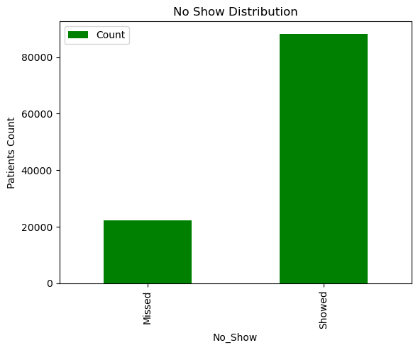

```python
def bar_plot(arg1, arg2):
    #No-Show bar graph
    arg1.iloc[:2,:1].plot(kind='bar', color='Green');
    plt.xlabel('No_Show')
    plt.ylabel('Patients Count')
    plt.title(f'{arg2.title()} Distribution');
    plt.legend();

bar_plot(No_Show_table, "No Show")
```

### Research Question 2 (How the following factors are important in order to predict if a patient will show up for their scheduled appointment?)

### 2-1 Gender

#### 2-1-1 Gender Summary Table

```python
# Extract Gender rows
df_GenderF = df[df['Gender'] == 'F']
df_GenderM = df[df['Gender'] == 'M']

# Gender summary table
F = len(df_GenderF)
M = len(df_GenderM)
Gender_Total = F + M

Gender_dic = { 'Count':[F, M, Gender_Total],
              'Percentage (%)':[F*100/Gender_Total, M*100/Gender_Total,
                                F*100/Gender_Total +M*100/Gender_Total]}
Gender_table = pd.DataFrame(Gender_dic)
index1 = ['Female', 'Male', 'Total']
Gender_table.index = index1

#show the table
print('Note: the Percentage of female and male is with respect to patients total')
Gender_table
```

```
Note: the Percentage of female and male is with respect to patients total
```

|  | Count | Percentage (%) |
| --- | --- | --- |
| Female | 71839 | 64.997376 |
| Male | 38687 | 35.002624 |
| Total | 110526 | 100.000000 |

#### 2-1-2 Gender Summary Graph

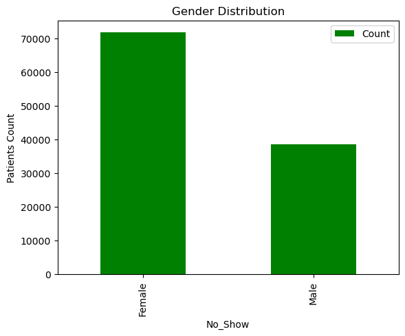

```python
#Gender bar graph
bar_plot(Gender_table, "Gender")
```

The Gender table and bar graph indicates that the number of female patients is greater than the number of male patients. With a simple calculation we can say that around two-third of the appointments in the dataset belongs to female patients.

#### 2-1-3 Gender Based on No_Show Summary Table

(**Note:** 'Yes' = missed || 'No' = showed)

```python
#group No_Show column with Gender column in a table
df.groupby('No_Show')['Gender'].value_counts()
```

```
No_Show  Gender
No       F         57245
         M         30962
Yes      F         14594
         M          7725
Name: count, dtype: int64
```

```python
print('Percentage of female and male with respect to each gender\'s total')
Female_per=df_GenderF['No_Show'].value_counts()*100/len(df_GenderF)
Male_per=df_GenderM['No_Show'].value_counts()*100/len(df_GenderM)

table_Gender_YN = pd.DataFrame([Female_per, Male_per])
table_Gender_YN.index=index1[0:2]

table_Gender_YN
```

```
Percentage of female and male with respect to each gender's total
```

| No_Show | No | Yes |
| --- | --- | --- |
| Female | 79.685129 | 20.314871 |
| Male | 80.032052 | 19.967948 |

#### 2-1-4 Gender Based on No_Show Graph

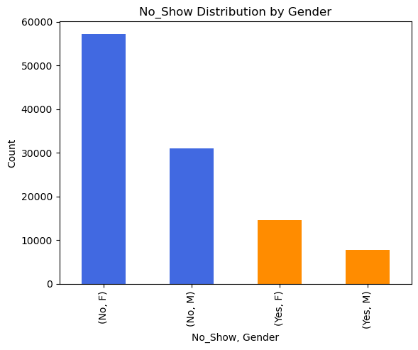

```python
#Plot No_Show data grouped with Gender data
df.groupby('No_Show')['Gender'].value_counts().plot(kind='bar', color=['royalblue','royalblue','darkorange', 'darkorange']);
plt.xlabel('No_Show, Gender')
plt.ylabel('Count')
plt.title('No_Show Distribution by Gender');
```

The two tables above and bar graph display normal no show performance for both genders. The females who showed up have the highest count and those who did not show up are 20% less than the total number of female patients. Also, 30962 of patients who met their appointments are male and are considered as 80% of the total number of male patients in the dataset.

### cont. Research Question 2 (How the following factors are important in order to predict if a patient will show up for their scheduled appointment?)

### 2-2 Age

#### 2-2-1 Overall Age Statistics

```python
#explore Age data
df['Age'].describe()
```

```
count    110526.000000
mean         37.089219
std          23.110026
min           0.000000
25%          18.000000
50%          37.000000
75%          55.000000
max         115.000000
Name: Age, dtype: float64
```

#### 2-2-2 Overall Age Histogram

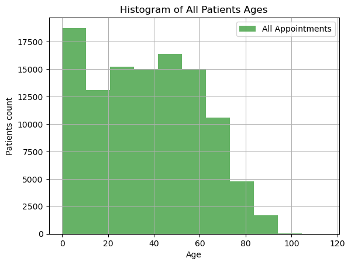

```python
#graph histogram for all patients
df['Age'].hist(alpha=0.6,bins=11,label='All Appointments', color='Green');
plt.xlabel("Age")
plt.ylabel("Patients count")
plt.title("Histogram of All Patients Ages");
plt.legend();
```

All the patients' ages constructed a right-skewed histogram, at which 50% of patients are less than 37 years old and 75% of them are less than 55 years old. The age group of children from 0 to 10 years old carry the highest number of patients from the sample under study then the number drastically fall for the next age group (between 10 and 21 years old). After that, it increased with few variations before the the age of 60.

#### 2-2-3 Age Histogram for People who Showed-up and Missed

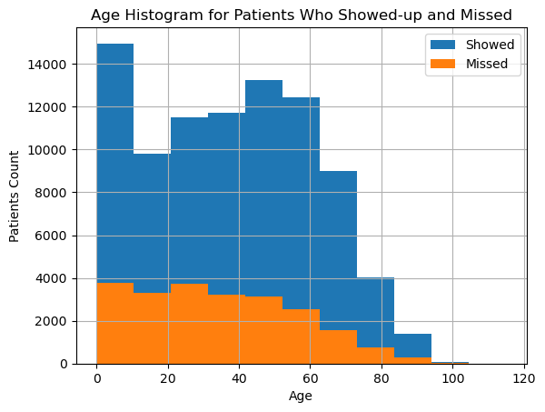

```python
#graph histogram after grouping No_Show and Age
df.groupby('No_Show')['Age'].hist(alpha=1.0,bins=11,label='Missed');
plt.xlabel("Age")
plt.ylabel("Patients Count")
plt.title("Age Histogram for Patients Who Showed-up and Missed")
plt.legend(['Showed','Missed']);
```

The histogram shape of showed up appointments is similar to all patients ages' histogram.

The histogram of missed appointments has lower number of counts distributed as right skewed, but it is a bit compacted, so, we'll next have a seperate figure for it.

#### 2-2-4 Age Histogram for People who Missed (No_Show = Yes)

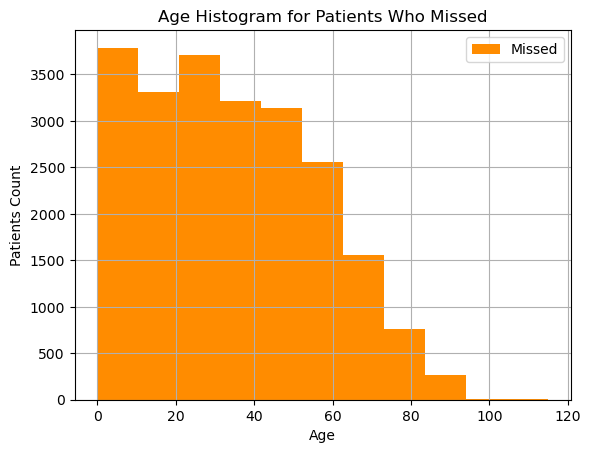

```python
#graph histogram after grouping No_Show=Yes and Age
df_No_ShowYes['Age'].hist(alpha=1.0,bins=11,label='Missed', color='darkorange');
plt.xlabel("Age")
plt.ylabel("Patients Count")
plt.title("Age Histogram for Patients Who Missed")
plt.legend();
```

Positively skewed histogram shape for patients who missed the appointments with peaks at two age groups, which are approximated to be (0-10) and (21-31) years old. In comparison to age histogram for patients who showed up, this graph displays a gradual decline after 40 years old tick.

#### 2-2-5 Age Boxplot for people who Showed-up and Missed

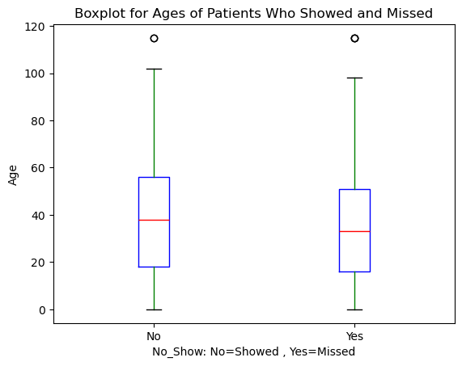

```python
#colors for the plot
color= dict(boxes='blue', whiskers='green', medians='red', caps='black')

#plot the boxplot
df.plot.box(column="Age", by="No_Show", color=color);
plt.xlabel("No_Show: No=Showed , Yes=Missed")
plt.ylabel("Age")
plt.title("Boxplot for Ages of Patients Who Showed and Missed");
```

### cont. Research Question 2 (How the following factors are important in order to predict if a patient will show up for their scheduled appointment?)

### 2-3 Neighbourhood

#### 2-3-1 Neigbourhood Distribution Based on No_Show Data

```python
df.groupby('No_Show')['Neighbourhood'].value_counts()
```

```
No_Show  Neighbourhood
No       JARDIM CAMBURI                 6252
         MARIA ORTIZ                    4586
         RESISTÊNCIA                    3525
         JARDIM DA PENHA                3246
         SANTA MARTHA                   2635
                                        ...
Yes      PONTAL DE CAMBURI                12
         ILHA DO BOI                       3
         ILHAS OCEÂNICAS DE TRINDADE       2
         ILHA DO FRADE                     2
         AEROPORTO                         1
Name: count, Length: 160, dtype: int64
```

#### 2-3-2 Neigbourhood Distribution for Patients who Showed (No_Show = No)

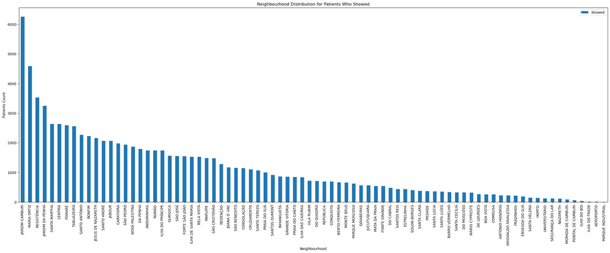

```python
df_No_ShowNo['Neighbourhood'].value_counts().plot(kind = 'bar', figsize=(30,10), label='showed');
plt.xlabel("Neighbourhood")
plt.ylabel("Patients Count")
plt.title("Neighbourhood Distribution for Patients Who Showed")
plt.legend();
```

The neighbourhood Jardim Canburi has the greatest showed up appointments (>6000 appointments.) Maria Ortiz comes next with more than 4500 appointments and Resistencia with more than 3500 appointments and so on. On the other hand, Ilha Do Frade, Aeroporto and Parque Industrial are among the lowest neighbourhood that have patients attending the appointments.

#### 2-3-3 Neigbourhood Distribution for Patients who Missed (No_Show = Yes)

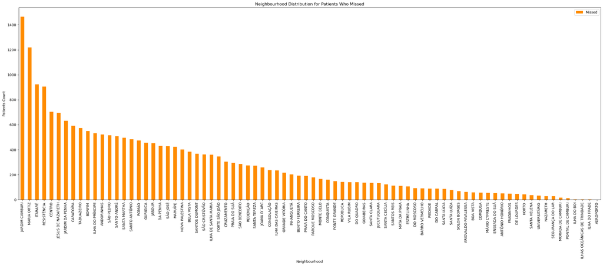

```python
df_No_ShowYes['Neighbourhood'].value_counts().plot(kind = 'bar', color= 'darkorange', figsize=(30,10), label='Missed');
plt.xlabel("Neighbourhood")
plt.ylabel("Patients Count")
plt.title("Neighbourhood Distribution for Patients Who Missed")
plt.legend();
```

The greatest number of patients missing the appointments are from Jardim Canburi(>1400 appointments), Maria Ortiz(>1200 appointments), Itarare and Resistencia(~900 appointments per each). Although, Ilhas Oceanicas De Trindade, Ilha Do Frade and Aeroporto are among the lowest neighbourhood with less than 3 missed appointments. Parque Industrial does not appear here in the graph compared to the previous one. It had zero appointments missing.

### cont. Research Question 2 (How the following factors are important in order to predict if a patient will show up for their scheduled appointment?)

### 2-4 Scholarship and SMS_Received

#### 2-4-1 Scholarship/SMS_Received Distribution Based on No_Show Data

```python
#calculate percent of scholarship
print('The percentage of patients who have Bolsa Familia(1) or not(0):\n', df['Scholarship'].value_counts()*100/110526)
```

```
The percentage of patients who have Bolsa Familia(1) or not(0):
 Scholarship
0    90.173353
1     9.826647
Name: count, dtype: float64
```

```python
#calculate percent of sms_received
print('The percentage of patients who have received an SMS(1) or not(0):\n', df['SMS_Received'].value_counts()*100/110526)
```

```
The percentage of patients who have received an SMS(1) or not(0):
 SMS_Received
0    67.897146
1    32.102854
Name: count, dtype: float64
```

```python
#summary Table
list0 = ['Scholarship', 'SMS_Received']
df.groupby('No_Show')[list0].value_counts()
```

```
No_Show  Scholarship  SMS_Received
No       0            0               56547
                      1               23377
         1            0                5962
                      1                2321
Yes      0            0               11141
                      1                8600
         1            0                1394
                      1                1184
Name: count, dtype: int64
```

#### 2-4-2 Pie chart of Scholarship/SMS_Received given No_Show Data

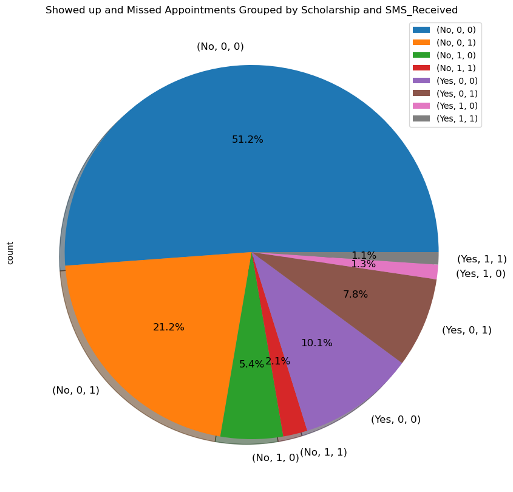

```python
#pie chart to relate the 'No_Show' with the 'Scholarship' and 'SMS_Received'
df.groupby('No_Show')[list0].value_counts().plot.pie(title='Showed up and Missed Appointments Grouped by Scholarship and SMS_Received',
                                                     legend=True, autopct='%1.1f%%', shadow=True, startangle=0, figsize=(10,10), fontsize=12);
```

From the sample size, those who did not have scholarships or receive SMSs are 51.2% showed up and 10.1% did not show up. The percentages of those who recieved SMSs only are 21.2% showed up and 7.8% missed their appointments. The patients who came to the appointments with scholarships are 5.4%, whereas 1.3% had scholarships and missed the appointments. 2.1% showed up the appointments with both, scholarships and SMSs, and less than that did not show up. For every conditions, the amount of appointments attended is greater than the missed ones.

### cont. Research Question 2 (How the following factors are important in order to predict if a patient will show up for their scheduled appointment?)

### 2-5 Health Issues (Hypertension, Diabetes and Alcoholism)

#### 2-5-1 Histogram for each Health Issue

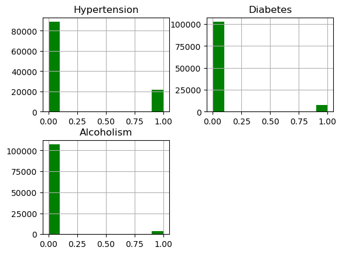

```python
#plot histogram for each issue
list1 = ['Hypertension', 'Diabetes', 'Alcoholism']
df[list1].hist(color='green');
```

All the issues are present with low number of patients count. However, hypertension appear higher than the others with more than 20000 cases; after that, diabetes and then alcoholism.

#### 2-5-2 Pie Chart of Health Issues Given Patients who Showed-up

**Note:** Each slice indicates whether the patient have or does not have the health issue. It comes in order; such that (Hypertension, Diabetes, Alcoholism). For example, (1,0,1) = patient with hypertension and alcoholism only.

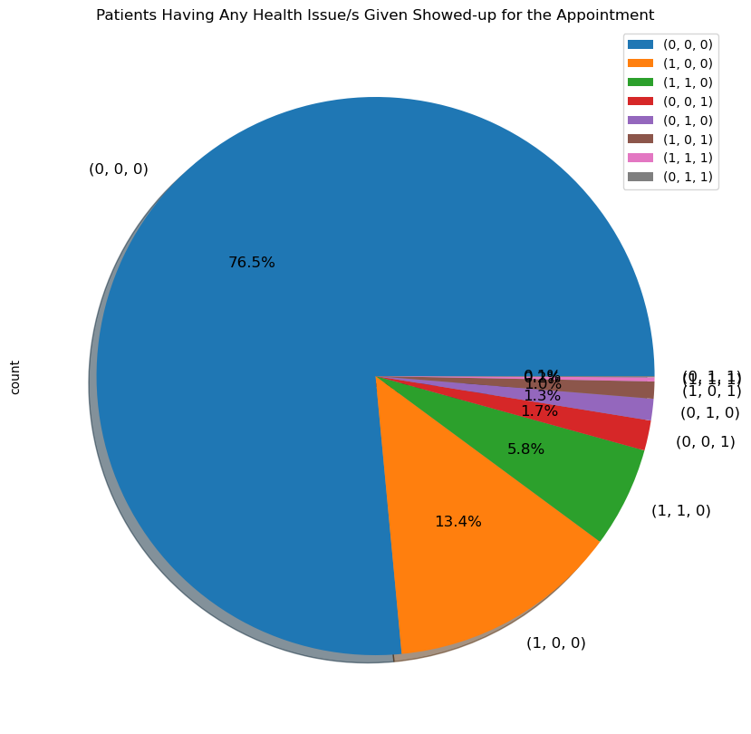

```python
df_No_ShowNo[list1].value_counts().plot.pie(title='Patients Having Any Health Issue/s Given Showed-up for the Appointment',
                                            legend=True, autopct='%1.1f%%', shadow=True, startangle=0, figsize=(10,10), fontsize=12);
```

The most important cases here is that 76.5% of the patients who shoed up had no health issues. Then, 13.4% of them had hypertension only and 5.8% had both hypertension anf diabetes. The other cases had a smaller impact on those who attended.

#### 2-5-3 Pie Chart of Health Issues Given Patients who Missed

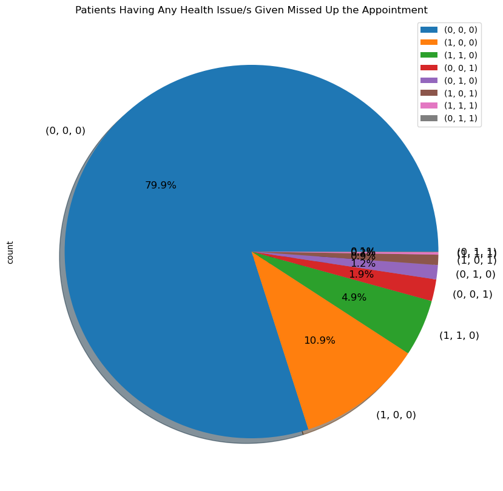

```python
df_No_ShowYes[list1].value_counts().plot.pie(title='Patients Having Any Health Issue/s Given Missed Up the Appointment',
                                             legend=True, autopct='%1.1f%%', shadow=True, startangle=0, figsize=(10,10), fontsize=12);
```

Like the order of cases in the previous pie chart, the most important case is 79.9% of the patients who did not attend the appointments had no health issues. Then, 10.9% of them had hypertension only and 4.9% had both hypertension anf diabetes. The other cases had a smaller impact on those who missed their appointments.

### Research Question 3 (How is the time difference between the scheduled day and appointment day affect patient attitude?)

### 3-1 Calculation of Time Difference

```python
#calculate the time difference
TimeDiff = df['AppointmentDay'] - df['ScheduledDay']
#add new column for number of days in the dataframe
df['num_days'] = TimeDiff.dt.days

#check the data
df.tail()
```

|  | PatientId | AppointmentID | Gender | ScheduledDay | AppointmentDay | Age | Neighbourhood | Scholarship | Hypertension | Diabetes | Alcoholism | Handicap | SMS_Received | No_Show | num_days |
| --- | --- | --- | --- | --- | --- | --- | --- | --- | --- | --- | --- | --- | --- | --- | --- |
| 110522 | 2572134369293 | 5651768 | F | 2016-05-03 09:15:35+00:00 | 2016-06-07 00:00:00+00:00 | 56 | MARIA ORTIZ | 0 | 0 | 0 | 0 | 0 | 1 | No | 34 |
| 110523 | 3596266328735 | 5650093 | F | 2016-05-03 07:27:33+00:00 | 2016-06-07 00:00:00+00:00 | 51 | MARIA ORTIZ | 0 | 0 | 0 | 0 | 0 | 1 | No | 34 |
| 110524 | 15576631729893 | 5630692 | F | 2016-04-27 16:03:52+00:00 | 2016-06-07 00:00:00+00:00 | 21 | MARIA ORTIZ | 0 | 0 | 0 | 0 | 0 | 1 | No | 40 |
| 110525 | 92134931435557 | 5630323 | F | 2016-04-27 15:09:23+00:00 | 2016-06-07 00:00:00+00:00 | 38 | MARIA ORTIZ | 0 | 0 | 0 | 0 | 0 | 1 | No | 40 |
| 110526 | 377511518121127 | 5629448 | F | 2016-04-27 13:30:56+00:00 | 2016-06-07 00:00:00+00:00 | 54 | MARIA ORTIZ | 0 | 0 | 0 | 0 | 0 | 1 | No | 40 |

```python
#expolre the numbers
df['num_days'].describe()
```

```
count    110526.000000
mean          9.183794
std          15.255034
min          -7.000000
25%          -1.000000
50%           3.000000
75%          14.000000
max         178.000000
Name: num_days, dtype: float64
```

We can see that minimum time is -7 days and 25% of appointments are less than -1 days. It's impossible to have a negative day. Let's see the data in the corresponding dates.

```python
#look at data where time difference is -1
df[df['num_days']==-1].head()
```

|  | PatientId | AppointmentID | Gender | ScheduledDay | AppointmentDay | Age | Neighbourhood | Scholarship | Hypertension | Diabetes | Alcoholism | Handicap | SMS_Received | No_Show | num_days |
| --- | --- | --- | --- | --- | --- | --- | --- | --- | --- | --- | --- | --- | --- | --- | --- |
| 0 | 29872499824296 | 5642903 | F | 2016-04-29 18:38:08+00:00 | 2016-04-29 00:00:00+00:00 | 62 | JARDIM DA PENHA | 0 | 1 | 0 | 0 | 0 | 0 | No | -1 |
| 1 | 558997776694438 | 5642503 | M | 2016-04-29 16:08:27+00:00 | 2016-04-29 00:00:00+00:00 | 56 | JARDIM DA PENHA | 0 | 0 | 0 | 0 | 0 | 0 | No | -1 |
| 2 | 4262962299951 | 5642549 | F | 2016-04-29 16:19:04+00:00 | 2016-04-29 00:00:00+00:00 | 62 | MATA DA PRAIA | 0 | 0 | 0 | 0 | 0 | 0 | No | -1 |
| 3 | 867951213174 | 5642828 | F | 2016-04-29 17:29:31+00:00 | 2016-04-29 00:00:00+00:00 | 8 | PONTAL DE CAMBURI | 0 | 0 | 0 | 0 | 0 | 0 | No | -1 |
| 4 | 8841186448183 | 5642494 | F | 2016-04-29 16:07:23+00:00 | 2016-04-29 00:00:00+00:00 | 56 | JARDIM DA PENHA | 0 | 1 | 1 | 0 | 0 | 0 | No | -1 |

It seems that all appointment days are made in the same corrosponding scheduled day and timed systematically at 00:00. I will treat the time difference of -1 as 0.

```python
#Look at data with time difference less than -1
df[df['num_days']<-1]
```

|  | PatientId | AppointmentID | Gender | ScheduledDay | AppointmentDay | Age | Neighbourhood | Scholarship | Hypertension | Diabetes | Alcoholism | Handicap | SMS_Received | No_Show | num_days |
| --- | --- | --- | --- | --- | --- | --- | --- | --- | --- | --- | --- | --- | --- | --- | --- |
| 27033 | 7839272661752 | 5679978 | M | 2016-05-10 10:51:53+00:00 | 2016-05-09 00:00:00+00:00 | 38 | RESISTÊNCIA | 0 | 0 | 0 | 0 | 1 | 0 | Yes | -2 |
| 55226 | 7896293967868 | 5715660 | F | 2016-05-18 14:50:41+00:00 | 2016-05-17 00:00:00+00:00 | 19 | SANTO ANTÔNIO | 0 | 0 | 0 | 0 | 1 | 0 | Yes | -2 |
| 64175 | 24252258389979 | 5664962 | F | 2016-05-05 13:43:58+00:00 | 2016-05-04 00:00:00+00:00 | 22 | CONSOLAÇÃO | 0 | 0 | 0 | 0 | 0 | 0 | Yes | -2 |
| 71533 | 998231581612122 | 5686628 | F | 2016-05-11 13:49:20+00:00 | 2016-05-05 00:00:00+00:00 | 81 | SANTO ANTÔNIO | 0 | 0 | 0 | 0 | 0 | 0 | Yes | -7 |
| 72362 | 3787481966821 | 5655637 | M | 2016-05-04 06:50:57+00:00 | 2016-05-03 00:00:00+00:00 | 7 | TABUAZEIRO | 0 | 0 | 0 | 0 | 0 | 0 | Yes | -2 |

Five rows are less than -1 time difference. It could be an error! No harm to the analysis if they are dropped.

```python
# Drop the patients no. 27033, 55226, 64175, 71533, 72362
df.drop([27033, 55226, 64175, 71533, 72362], axis = 0, inplace = True)

#check if it is dropped
df[df['num_days']<-1]
```

|  | PatientId | AppointmentID | Gender | ScheduledDay | AppointmentDay | Age | Neighbourhood | Scholarship | Hypertension | Diabetes | Alcoholism | Handicap | SMS_Received | No_Show | num_days |
| --- | --- | --- | --- | --- | --- | --- | --- | --- | --- | --- | --- | --- | --- | --- | --- |

```python
#expolre the numbers again
df['num_days'].describe()
```

```
count    110521.000000
mean          9.184345
std          15.255153
min          -1.000000
25%          -1.000000
50%           3.000000
75%          14.000000
max         178.000000
Name: num_days, dtype: float64
```

### 3-2 Histogram of Time Difference

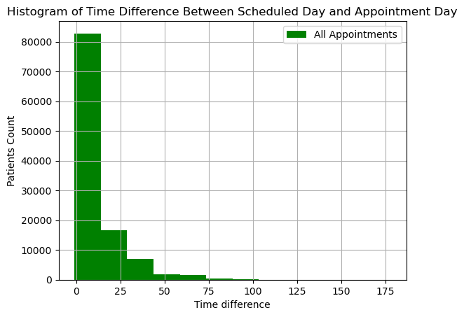

```python
#Explore overall histogram
df['num_days'].hist(alpha=1,bins=12,label='All Appointments', color='green')
plt.xlabel("Time difference")
plt.ylabel("Patients Count")
plt.title("Histogram of Time Difference Between Scheduled Day and Appointment Day")
plt.legend();
```

The time difference data are interesting, where three-quarter the number of appointments fall at less than 2-weeks (or 14 days) time between the scheduled day and appointment day. Moreover, 50% of the appointments had 3 and less days difference.

### 3-3 Histograms of Time Difference for Showed up and Missed Appointments

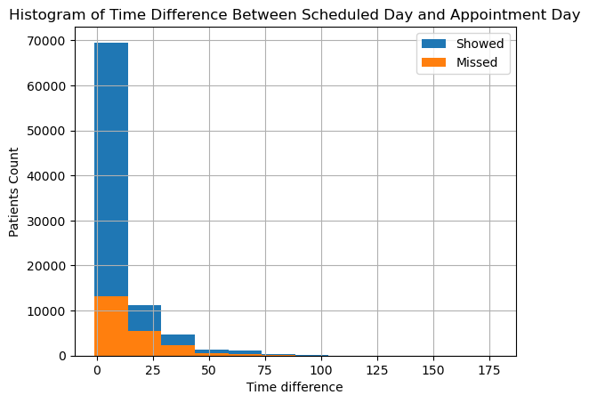

```python
#make histograms for each No_Show decisions
df.groupby('No_Show')['num_days'].hist(alpha=1,bins=12,label='Showed');
plt.xlabel("Time difference")
plt.ylabel("Patients Count")
plt.title("Histogram of Time Difference Between Scheduled Day and Appointment Day")
plt.legend(['Showed','Missed']);
```

```python
#explore time difference for both decisions
df.groupby('No_Show')['num_days'].describe()
```

| No_Show | count | mean | std | min | 25% | 50% | 75% | max |
| --- | --- | --- | --- | --- | --- | --- | --- | --- |
| No | 88207.0 | 7.754759 | 14.55045 | -1.0 | -1.0 | 1.0 | 11.0 | 178.0 |
| Yes | 22314.0 | 14.835484 | 16.60560 | -1.0 | 3.0 | 10.0 | 22.0 | 178.0 |

The histograms are right skewed that shows most of the appointments attended and missed are within the time difference of -1 and 25 days. large amount of the appointments attended had time difference of 11 days and less, while most of the appointments missed had time difference of 22 or less days. Therefore, the lower the time difference between scheduled day and appointment day, the better the attendance performance.

## Conclusions

This study includes data from 110526 appointments scheduled between 2015-11-10 and 2016-8-6 for the patients in Brazil. In this section,the data Analysis explored in the previous section are discussed.

Overall, the number of the appointments that has been met by patients is higher than the missed ones; that is around 80% of the patients showed up whereas 20% of them missed their appointments. 22319 appointments scheduled in less then 7 months were missed. Therefore, it is vital to figure out the reasons behind these numbers. To do so, this project analysed how several factors help in predicting if patients will show up for their scheduled appointment. The factors examined are 'Gender', 'Age', 'Neighbourhood', 'Scholarship', 'SMS_Received', 'Hypertension', 'Diabetes', 'Alcoholism' and time difference between scheduled day and appointment day.

**Gender:** Firstly, the gender statistics of patients participated are approximately 65% female and 35% male. The bar graph shows that the number of female patients showed up or missed is almost double the number of the corrosponding male patients; probably due to the higher percentage of females in the sample size. Both male and female appointments have the similar rates of missed appointments, which is almost 20% of the corresponding total appointments. This leads to the result that gender does not have a clear correlation to the patient decision whether to show up for an appointment or not.

**Neighbourhood:** Neighbourhood was also explored; the bar charts show that Jardim Cumburi has the highest showed up appointments (around 6252) as well as the highest missed appointments (around 1465); that is the missed is 20% of the total appointments from the city. To generalise, for every city the number of attended appointments is higher than the number of the missed except for the cities with very low number of scheduled appointments. There isn't a correlation from this set of data. However, I believe, there are some limitations; we need extra parameters to improve the quality of this finding, for example, the distance of the neighbourhood from the hospital.

**Time Difference between Scheduled Day and Appointment Day:** In the last question, the time difference between scheduled day and appointment day was analysed (I will call it time difference in this context). Regardless of patients decision, the histogram of time difference has a positively skewed shape at which most of the sample size is concentrated to the left side, which shows that 75% of appointments were less than 14 days away from their scheduled day. Showed-up and missed appointments time difference histograms are also positively skewed. 75% of time difference is less than 11 days for showed-up Appointments whereas a higher value of 22 days for missed appointments. Therefore, there is a large probability that patients will attend their appointments if the time difference between scheduled day and appointment day is lower than 11 days.

All in all, the most effective factor to help in predict if the patient will commit to the appointments is 'Time Difference between Scheduled Day and Appointment Day'.

## References

- Data Fandumentals course, Udacity, 2024.
- Medical Appointment No Shows Data Set, https://www.kaggle.com/joniarroba/noshowappointments&sa=D&ust=1532469042118000, Kaggle, 2016.
- Bolsa Família, https://en.wikipedia.org/wiki/Bolsa_Fam%C3%ADlia, Wikipedia, 2023